# MS Fees 2019

Adrian D. Garcia

June 2020

```r
library(tidyverse) #For Data Analysis
library(lubridate) #For working with dates
library(DT) #For visualizing tables
```

First, I pull in the data from Morningstar Direct (combined using “Combine_Files.r”). There are 25,654 rows and 96 columns. Data was pulled from Morningstar Direct on June 12, 2020.

```r
Full <- read_csv("DIRECT/MS_Fee_Report_061220.csv",
                 guess_max = 5000)
```

I’m making the following adjustment to the data:

-Calculate the average assets for 2017, 2018 and 2019. -Calculate the percent change in net expense ratios from 2018 to 2019 -Multipy the annual average asset figures by the expense ratio (to use later for asset-weighted calculations)

Here I want to look how deep firms slashed pay ratios from 2018 to 2019. First, remove rows with an expense ratio of zero in 2018 because I can’t calculate changes with that base. I also filter out expense ratios listed as NA (blank) for 2018 and 2019.

Now I need to put the percent change in fees from 2018 to 2019 into buckets. I did that with the cut() function. Here’s a for personal reference: https://rpubs.com/pierrelafortune/cutdocumentation

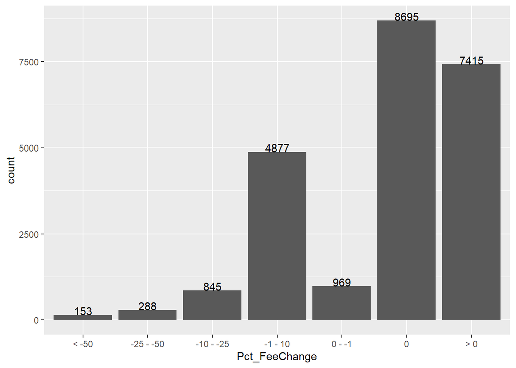

```r
Category <- Adjusted_Data %>%
  select(
    1:20,
    86:96
  ) %>%
  filter(
    `Annual Report \nNet Expense \nRatio \nYear2018` != 0 &
      !is.na(`Annual Report \nNet Expense \nRatio \nYear2018`) &
      !is.na(`Annual Report \nNet Expense \nRatio \nYear2019`)
  ) %>%
  mutate(
    Pct_FeeChange =
      cut(Change_2018_2019,
          breaks = c(-Inf,-50,-25,-10,-1,-0.01,0,Inf),
          labels = c("< -50", "-25 - -50", "-10 - -25", "-1 - 10","0 - -1", "0", "> 0"),
          include.lowest = TRUE,
          right = TRUE
      )
  )

Summary_Category <- Category %>%
  group_by(Pct_FeeChange) %>%
  summarise(count = n())

ggplot(data = Summary_Category, mapping = aes(x = Pct_FeeChange, y = count)) +
  geom_bar(stat = "identity") +
  geom_text(aes(label = count), vjust = 0)
```

Here I am looking at the fund families that with the lowest and highest overall fees across active products. I start by filtering out index funds and removing fees that are NA (blank) for 2019. Next I group the data by firm, sum their adjusted assets, sum their net assets and divide the total adjusted data by the total net asssets to calculate asset-weighted fees for each fund shop. I select the top and bottom 15 fund families based on the results.

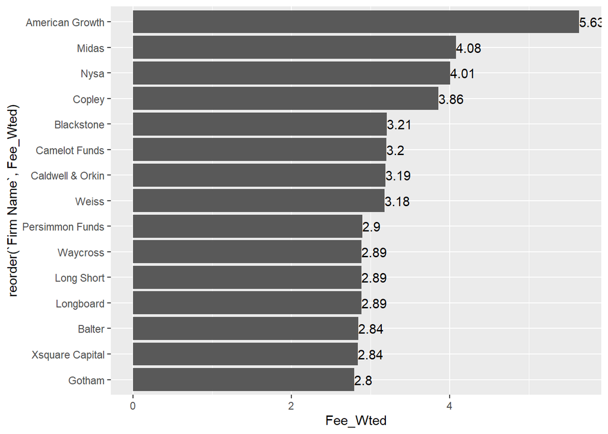

```r
ActiveFunds <- Adjusted_Data %>%
  filter(
    `Index \nFund` != "Yes" &
            !is.na(`Annual Report \nNet Expense \nRatio \nYear2019`)

  )

Active_Fees <- ActiveFunds %>%
  group_by(`Firm Name`) %>%
  summarise(
    Sum_Assts_Wted = sum(Asst_By_Fee_2019, na.rm = TRUE),
    Sum_Assets = sum(Net_Asst_2019_AVG, na.rm = TRUE),
    Fee_Wted = Sum_Assts_Wted/Sum_Assets
  )

Active_HighFees <- Active_Fees %>%
  arrange(desc(Fee_Wted)) %>%
  top_n(15, Fee_Wted)

Active_LowFees <- Active_Fees %>%
  arrange(Fee_Wted) %>%
  top_n(-15, Fee_Wted)

ggplot(data = Active_HighFees, mapping = aes(x = reorder(`Firm Name`, Fee_Wted), y = Fee_Wted)) +
  geom_bar(stat="identity") +
  coord_flip() +
  geom_text(aes(label = round(Fee_Wted,2)), hjust = 0)
```

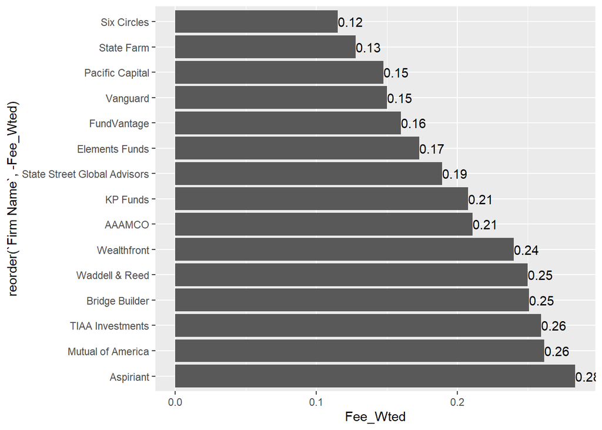

```r
ggplot(data = Active_LowFees, mapping = aes(x = reorder(`Firm Name`, -Fee_Wted), y = Fee_Wted)) +
  geom_bar(stat="identity") +
  coord_flip() +
  geom_text(aes(label = round(Fee_Wted,2)), hjust = 0)
```

Here I am looking at the fund families that with the lowest and highest overall fees across passive products. I start by filtering out non-index funds and removing fees that are NA (blank) for 2019. Next I group the data by firm, sum their adjusted assets, sum their net assets and divide the total adjusted data by the total net asssets to calculate asset-weighted fees for each fund shop. I select the top and bottom 15 fund families based on the results.

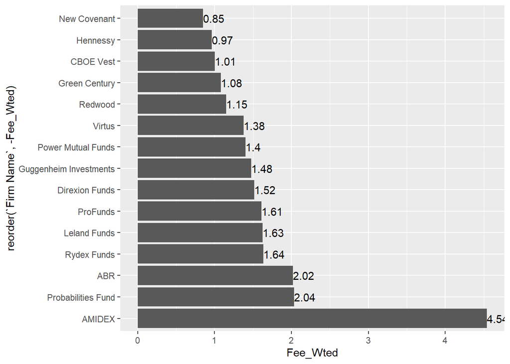

```r
PassiveFunds <- Adjusted_Data %>%
  filter(
    `Index \nFund` != "No" &
      !is.na(`Annual Report \nNet Expense \nRatio \nYear2019`)
  )

Passive_Fees <- PassiveFunds %>%
  group_by(`Firm Name`) %>%
  summarise(
    Sum_Assts_Wted = sum(Asst_By_Fee_2019, na.rm = TRUE),
    Sum_Assets = sum(Net_Asst_2019_AVG, na.rm = TRUE),
    Fee_Wted = Sum_Assts_Wted/Sum_Assets
  )

Passive_HighFees <- Passive_Fees %>%
  arrange(desc(Fee_Wted)) %>%
  top_n(15)

Passive_LowFees <- Passive_Fees %>%
  arrange(Fee_Wted) %>%
  top_n(-15)

ggplot(data = Passive_HighFees, mapping = aes(x = reorder(`Firm Name`, -Fee_Wted), y = Fee_Wted)) +
  geom_bar(stat="identity") +
  coord_flip() +
  geom_text(aes(label = round(Fee_Wted,2)), hjust = 0)
```

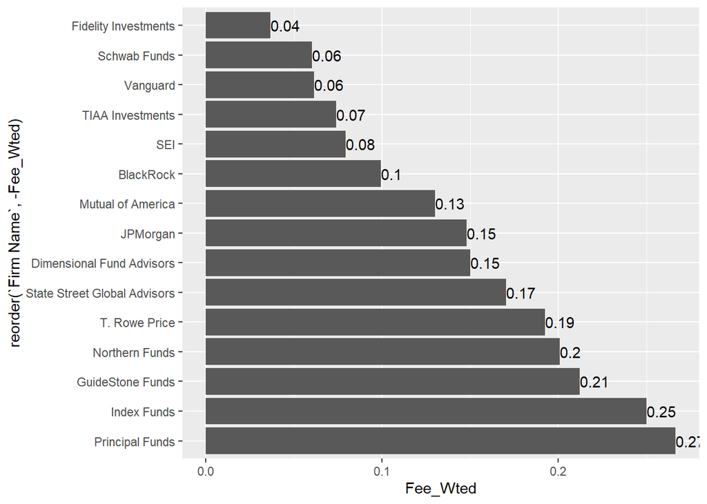

```r
ggplot(data = Passive_LowFees, mapping = aes(x = reorder(`Firm Name`, -Fee_Wted), y = Fee_Wted)) +
  geom_bar(stat="identity") +
  coord_flip() +
  geom_text(aes(label = round(Fee_Wted,2)), hjust = 0)
```

Here I am looking at how many share classes had fees that were cut and hiked as well as saw no change. I start by filtering out fees that are NA (blank) for 2019 and 2018. I also remove fees with a zero expense ratio for 2018 because we can’t calculate change with that base. Next I create a category (Pct_FeeChange) that puts the percent changes (continous) in buckets (categorical). After that I just count the buckets.

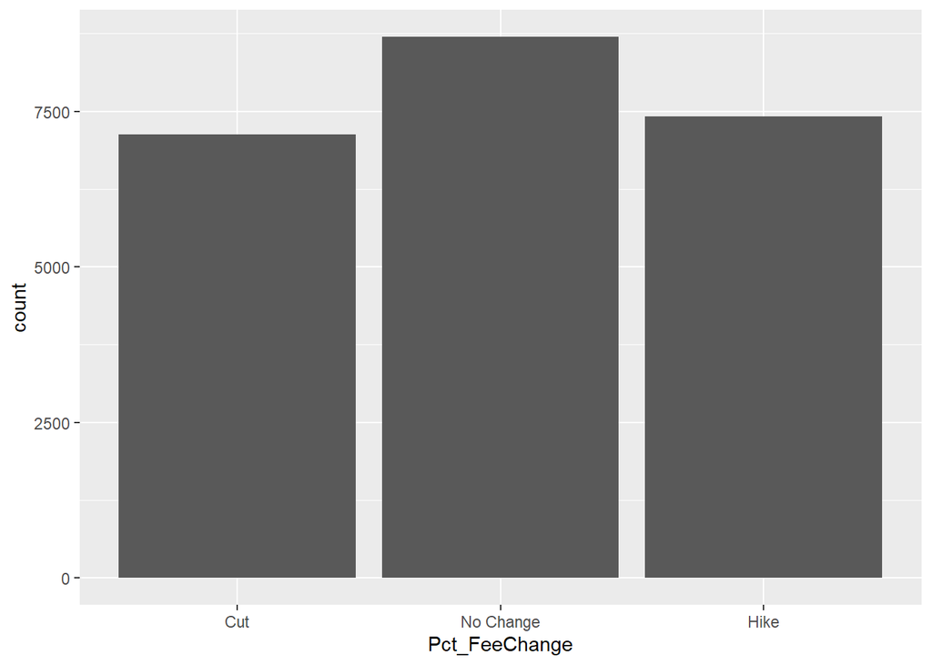

```r
Shareclass <- Adjusted_Data %>%
  filter(
    `Annual Report \nNet Expense \nRatio \nYear2018` != 0 &
      !is.na(`Annual Report \nNet Expense \nRatio \nYear2018`) &
      !is.na(`Annual Report \nNet Expense \nRatio \nYear2019`)
  ) %>%
  mutate(
    Pct_FeeChange =
      cut(Change_2018_2019,
          breaks = c(-Inf,-0.001,0,Inf),
          labels = c("Cut", "No Change", "Hike"),
          include.lowest = TRUE,
          right = TRUE
      )
  )

Summary_Shareclass <- Shareclass %>%
  group_by(`Firm Name`,
           Pct_FeeChange) %>%
  summarise(count = n())

ggplot(data = Summary_Shareclass, mapping = aes(x = Pct_FeeChange, y = count)) +
  geom_bar(stat = "identity")
```

Here I am looking at how many Passive share classes had fees that were cut and hiked as well as saw no change. I start by filtering out non-index funds and fees that are NA (blank) for 2019 and 2018. I also remove fees with a zero expense ratio for 2018 because we can’t calculate change with that base. Next I create a category (Pct_FeeChange) that puts the percent changes (continous) in buckets (categorical). After that I just count the buckets.

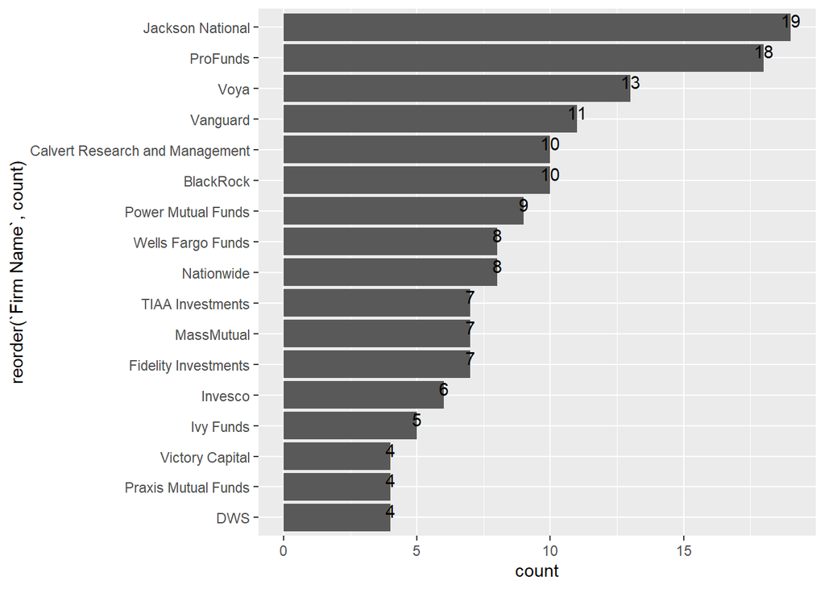

```r
Passive_Shareclass <- Adjusted_Data %>%
  filter(
    `Annual Report \nNet Expense \nRatio \nYear2018` != 0 &
      !is.na(`Annual Report \nNet Expense \nRatio \nYear2018`) &
      !is.na(`Annual Report \nNet Expense \nRatio \nYear2019`) &
      `Index \nFund` == "Yes"
  ) %>%
  mutate(
    Pct_FeeChange =
      cut(Change_2018_2019,
          breaks = c(-Inf,-0.001,0,Inf),
          labels = c("Cut", "No Change", "Hike"),
          include.lowest = TRUE,
          right = TRUE
      )
  )

Passive_Summary_Shareclass <- Passive_Shareclass %>%
  group_by(`Firm Name`,
           Pct_FeeChange) %>%
  summarise(count = n()) %>%
  group_by(`Firm Name`) %>%
  mutate(
    pct = count/sum(count)*100)

Passive_Summary_Shareclass %>%
  filter(Pct_FeeChange == "Cut") %>%
  arrange(desc(count)) %>%
  ungroup() %>%
  top_n(15, count) %>%
ggplot(mapping = aes(x = reorder(`Firm Name`, count), y = count)) +
  geom_bar(stat = "identity") +
  coord_flip() +
  geom_text(aes(label = count), vjust = 0)
```

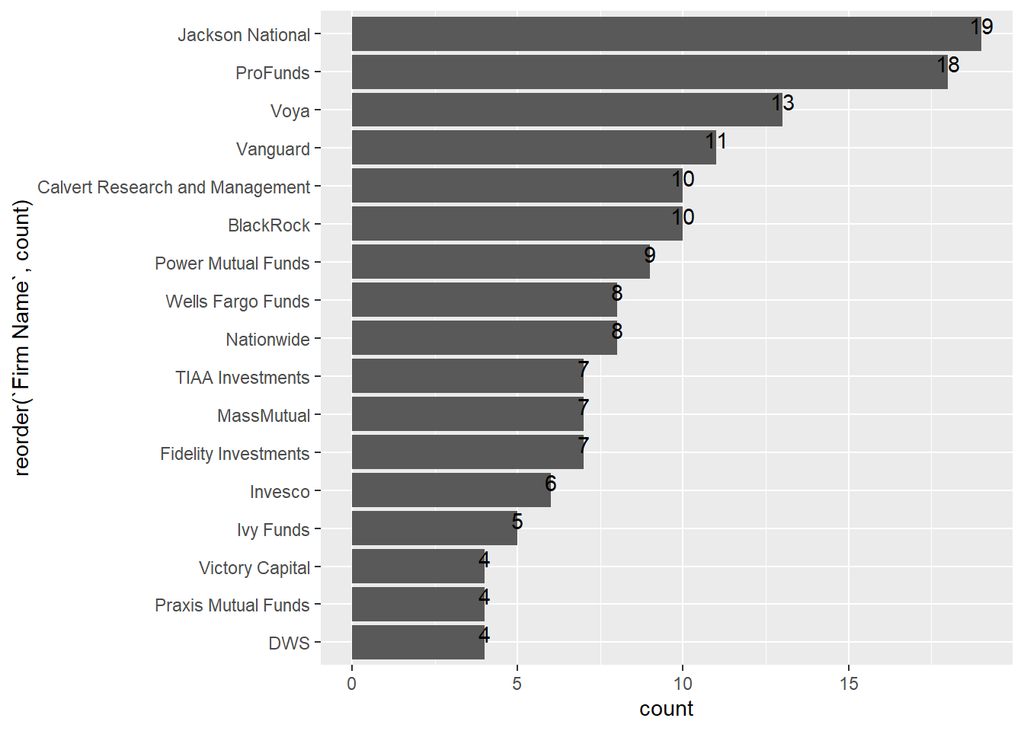

```r
Active_Shareclass <- Adjusted_Data %>%
  filter(
    `Annual Report \nNet Expense \nRatio \nYear2018` != 0 &
      !is.na(`Annual Report \nNet Expense \nRatio \nYear2018`) &
      !is.na(`Annual Report \nNet Expense \nRatio \nYear2019`) &
      `Index \nFund` == "Yes"
  ) %>%
  mutate(
    Pct_FeeChange =
      cut(Change_2018_2019,
          breaks = c(-Inf,-0.001,0,Inf),
          labels = c("Cut", "No Change", "Hike"),
          include.lowest = TRUE,
          right = TRUE
      )
  )

Active_Summary_Shareclass <- Active_Shareclass %>%
  group_by(`Firm Name`,
           Pct_FeeChange) %>%
  summarise(count = n()) %>%
  group_by(`Firm Name`) %>%
  mutate(
    pct = count/sum(count)*100)

Active_Summary_Shareclass %>%
  filter(Pct_FeeChange == "Cut") %>%
  arrange(desc(count)) %>%
  ungroup() %>%
  top_n(15, count) %>%
ggplot(mapping = aes(x = reorder(`Firm Name`, count), y = count)) +
  geom_bar(stat = "identity") +
  coord_flip() +
  geom_text(aes(label = count), vjust = 0)
```